# We Rate Dogs twitter analysis

## Project 2 : WRANGLE and ANALYZE Data

The dataset that you will be wrangling (and analyzing and visualizing) is the tweet archive of Twitter user dog_rates, also known as WeRateDogs WeRateDogs is a Twitter account that rates people's dogs with a humorous comment about the dog. These ratings almost always have a denominator of 10. The numerators, though? Almost always greater than 10. 11/10, 12/10, 13/10, etc. Why? Because "they're good dogs Brent." WeRateDogs has over 4 million followers and has received international media coverage.

Project Steps Overview

- Step 1: Gathering data
  - Archive data
  - Images data
  - Tweeter api data
- Step 2: Assessing data
  - Archive data
  - Images data
  - Tweeter api data
- Step 3: Cleaning data
  - Tidy issue
  - Quality issue
- Step 4: Storing data
- Step 5: Analyzing, and visualizing data

### What are the desired outputs of the project?

Your goal: wrangle WeRateDogs Twitter data to create interesting and trustworthy analyses and visualizations. The Twitter archive is great, but it only contains very basic tweet information. Additional gathering, then assessing and cleaning is required for "Wow!"-worthy analyses and visualizations.

### What Questions Are We Trying To Answer?

- 1. Which are the more popular doggo breeds?
- 2. Whats the correlation between Favorite count and retweet counts ?
- 3. Are the ratings Standadized ?

```python
# Iniallizing : Importing the required Libraries

import pandas as pd
import numpy as np
from numpy import median

import matplotlib.pyplot as plt
%matplotlib inline
import matplotlib.dates as mdates
import seaborn as sns
import time

from functools import reduce



import requests
from requests.exceptions import HTTPError
from timeit import default_timer as timer
import tweepy
from tweepy import OAuthHandler
import os
import json
import sys


from sklearn.feature_extraction import _stop_words
from sklearn.feature_extraction.text import ENGLISH_STOP_WORDS

#from _stop_words import  ENGLISH_STOP_WORDS
from datetime import datetime
from config import Config
import re
```

# Gathering data

This step involves gathering and loading data, there are three data set needed for this project the Tweeter archive data, the image data sets and the gathered data from the API

Tweeter archive data

```
This is the data obtained from the WeRateDogs twitter account udacity downloaded these data and made it available for this project
```

```python
# the tweet data
df_arch = pd.read_csv('twitter-archive-enhanced.csv')
```

Image Data

- programatically loading the image dataset

```python
#Retreiving the image predictions from Udacity server
r = requests.get('https://d17h27t6h515a5.cloudfront.net/topher/2017/August/599fd2ad_image-predictions/image-predictions.tsv', auth=('user', 'pass'))
r.status_code
```

```
200
```

```python
r.headers['content-type']
```

```
'text/tab-separated-values; charset=utf-8'
```

```python
r.encoding
```

```
'utf-8'
```

```python
r.text
```

```
"tweet_id\tjpg_url\timg_num\tp1\tp1_conf\tp1_dog\tp2\tp2_conf\tp2_dog\tp3\tp3_conf\tp3_dog\n666020888022790149\thttps://pbs.twimg.com/media/CT4udn0WwAA0aMy.jpg\t1\tWelsh_springer_spaniel\t0.465074\tTrue\tcollie\t0.156665\tTrue\tShetland_sheepdog\t0.0614285\tTrue\n666029285002620928\thttps://pbs.twim…
```

```python
# Saving the obtained data
with open('image-predictions.tsv', 'wb') as file:
    file.write(r.content)
```

```python
#load them as a dataframe
df_image = pd.read_csv('image-predictions.tsv', sep='\t')
```

Gathered data from API

- Create API object to use to get the Twitter data. I have used a function to do this so as not to share my Twitter consumer key and access token replaced it with hidden

```python
#configure the api

# Query Twitter API for each tweet in the Twitter archive and save JSON in a text file
# These are hidden to comply with Twitter's API terms and conditions
consumer_key = 'hidden'
consumer_secret = 'hidden'
access_token = 'hidden'
access_secret = 'hidden'


auth = OAuthHandler(consumer_key, consumer_secret)
auth.set_access_token(access_token, access_secret)
api = tweepy.API(auth, wait_on_rate_limit=True, parser=tweepy.parsers.JSONParser())
```

```python
#loop through each tweet id in the dr_arch df
#with open('tweet_json.txt','w') as outfile:
    # call infos
 #   for i in df_arch['tweet_id']:
        # handling exception
  #      try:
   #         tweet = api.get_status(i,tweet_mode='extended')
    #        json.dump(tweet._json, outfile)
     #       outfile.write("\n")
      #  except:
       #     e = os.sys.exc_info()[0]

# inspiration from try/except : https://wiki.python.org/moin/HandlingExceptions
```

```
After this step we open the saved file and convert to a pandas dataframe
```

```python
#open the saved json file
with open(os.path.join('tweet_json.txt')) as f:
    df_gat_data = json.load(f)


#convert the json_data file to a pandas data frame
df_gat_data = pd.DataFrame(df_gat_data, columns=['id', 'date', 'retweet_cnt', 'favorite_cnt', 'followers'])
```

```python
df_gat_data
```

|  | id | date | retweet_cnt | favorite_cnt | followers |
| --- | --- | --- | --- | --- | --- |
| 0 | 892420643555336193 | 2017-08-01 16-23-56 | 8259 | 37853 | 7794034 |
| 1 | 892177421306343426 | 2017-08-01 00-17-27 | 6103 | 32526 | 7794034 |
| 2 | 891815181378084864 | 2017-07-31 00-18-03 | 4041 | 24490 | 7794034 |
| 3 | 891689557279858688 | 2017-07-30 15-58-51 | 8410 | 41206 | 7794034 |
| 4 | 891327558926688256 | 2017-07-29 16-00-24 | 9108 | 39388 | 7794034 |
| ... | ... | ... | ... | ... | ... |
| 2335 | 666049248165822465 | 2015-11-16 00-24-50 | 42 | 106 | 7794002 |
| 2336 | 666044226329800704 | 2015-11-16 00-04-52 | 136 | 292 | 7794002 |
| 2337 | 666033412701032449 | 2015-11-15 23-21-54 | 43 | 123 | 7794002 |
| 2338 | 666029285002620928 | 2015-11-15 23-05-30 | 46 | 125 | 7794002 |
| 2339 | 666020888022790149 | 2015-11-15 22-32-08 | 498 | 2529 | 7794002 |

2340 rows × 5 columns

# Assesment

We will assess both visually and progrmmatically the loaded dataframes and find mistakes

Archive data Images data Tweeter api data

### The Archive data

```python
df_arch.head()
```

|  | tweet_id | in_reply_to_status_id | in_reply_to_user_id | timestamp | source | text | retweeted_status_id | retweeted_status_user_id | retweeted_status_timestamp | expanded_urls | rating_numerator | rating_denominator | name | doggo | floofer | pupper | puppo |
| --- | --- | --- | --- | --- | --- | --- | --- | --- | --- | --- | --- | --- | --- | --- | --- | --- | --- |
| 0 | 892420643555336193 | NaN | NaN | 2017-08-01 16:23:56 +0000 | <a href="http://twitter.com/download/iphone" r... | This is Phineas. He's a mystical boy. Only eve... | NaN | NaN | NaN | https://twitter.com/dog_rates/status/892420643... | 13 | 10 | Phineas | None | None | None | None |
| 1 | 892177421306343426 | NaN | NaN | 2017-08-01 00:17:27 +0000 | <a href="http://twitter.com/download/iphone" r... | This is Tilly. She's just checking pup on you.... | NaN | NaN | NaN | https://twitter.com/dog_rates/status/892177421... | 13 | 10 | Tilly | None | None | None | None |
| 2 | 891815181378084864 | NaN | NaN | 2017-07-31 00:18:03 +0000 | <a href="http://twitter.com/download/iphone" r... | This is Archie. He is a rare Norwegian Pouncin... | NaN | NaN | NaN | https://twitter.com/dog_rates/status/891815181... | 12 | 10 | Archie | None | None | None | None |
| 3 | 891689557279858688 | NaN | NaN | 2017-07-30 15:58:51 +0000 | <a href="http://twitter.com/download/iphone" r... | This is Darla. She commenced a snooze mid meal... | NaN | NaN | NaN | https://twitter.com/dog_rates/status/891689557... | 13 | 10 | Darla | None | None | None | None |
| 4 | 891327558926688256 | NaN | NaN | 2017-07-29 16:00:24 +0000 | <a href="http://twitter.com/download/iphone" r... | This is Franklin. He would like you to stop ca... | NaN | NaN | NaN | https://twitter.com/dog_rates/status/891327558... | 12 | 10 | Franklin | None | None | None | None |

- visually assesing the data set

```python
df_arch.info()
```

```
<class 'pandas.core.frame.DataFrame'>
RangeIndex: 2356 entries, 0 to 2355
Data columns (total 17 columns):
 #   Column                      Non-Null Count  Dtype
---  ------                      --------------  -----
 0   tweet_id                    2356 non-null   int64
 1   in_reply_to_status_id       78 non-null     float64
 2   in_reply_to_user_id         78 non-null     float64
 3   timestamp                   2356 non-null   object
 4   source                      2356 non-null   object
 5   text                        2356 non-null   object
 6   retweeted_status_id         181 non-null    float64
 7   retweeted_status_user_id    181 non-null    float64
 8   retweeted_status_timestamp  181 non-null    object
 9   expanded_urls               2297 non-null   object
 10  rating_numerator            2356 non-null   int64
 11  rating_denominator          2356 non-null   int64
 12  name                        2356 non-null   object
 13  doggo                       2356 non-null   object
 14  floofer                     2356 non-null   object
 15  pupper                      2356 non-null   object
 16  puppo                       2356 non-null   object
dtypes: float64(4), int64(3), object(10)
memory usage: 313.0+ KB
```

Observation :

- The timestamp is datatype should be changed
- There are retweets
- tweet id is int

```python
#finding if the are duplicated data in the data set
#it si important that there are no duplicated id in the data set
df_arch.tweet_id.duplicated().sum(), df_arch.duplicated().sum()
```

```
(0, 0)
```

```python
#finding the unique count of the numerator and denomintator
df_arch.rating_numerator.value_counts()
df_arch.rating_denominator.value_counts()
```

```
10     2333
11        3
50        3
20        2
80        2
70        1
7         1
15        1
150       1
170       1
0         1
90        1
40        1
130       1
110       1
16        1
120       1
2         1
Name: rating_denominator, dtype: int64
```

Observation:

- there are inconsitency in the numerator and denomerator: We can see that a number of ratings do not have the denominator value as 10

```python
# Defining Stop Words function

def stop_words(data_frame_column,name):
    '''
    take a data frame column and a column name
    and print the number of stop words in the column
    '''
    count=0
    for word in data_frame_column:
        if word in ENGLISH_STOP_WORDS:
            count+=1
    print('The column ',name,' has ',count,' stop words.')
```

```python
# Here we check the count of stop-words for each of the columns

stop_words(df_arch['tweet_id'],'tweet_id')
stop_words(df_arch['timestamp'],'timestamp')
stop_words(df_arch['source'],'source')
stop_words(df_arch['expanded_urls'],'expanded_urls')
stop_words(df_arch['rating_numerator'],'rating_numerator')
stop_words(df_arch['rating_denominator'],'rating_denominator')
stop_words(df_arch['name'],'name')
stop_words(df_arch['doggo'],'doggo')
stop_words(df_arch['floofer'],'floofer')
stop_words(df_arch['pupper'],'pupper')
stop_words(df_arch['puppo'],'puppo')
```

```
The column  tweet_id  has  0  stop words.
The column  timestamp  has  0  stop words.
The column  source  has  0  stop words.
The column  expanded_urls  has  0  stop words.
The column  rating_numerator  has  0  stop words.
The column  rating_denominator  has  0  stop words.
The column  name  has  87  stop words.
The column  doggo  has  0  stop words.
The column  floofer  has  0  stop words.
The column  pupper  has  0  stop words.
The column  puppo  has  0  stop words.
```

Observation :

- The name column has 87 stop words

```python
# by visually looking at the data we can see none
# by programatically looking at the data we define a function to detect the presence of 'None' string

def detect_none(data_frame_column,name):
    '''
    take a data frame column and a column name
    and print the number of 'None' string in the column
    '''
    count=0
    for word in data_frame_column:
        if word == 'None':
            count+=1
    print('The Column ', name, ' has ',count,'None entries present.')
```

```python
# Calling the detect_none function defined above

detect_none(df_arch['tweet_id'],'tweet_id')
detect_none(df_arch['timestamp'],'timestamp')
detect_none(df_arch['source'],'source')
detect_none(df_arch['expanded_urls'],'expanded_urls')
detect_none(df_arch['rating_numerator'],'rating_numerator')
detect_none(df_arch['rating_denominator'],'rating_denominator')
detect_none(df_arch['name'],'name')
detect_none(df_arch['doggo'],'doggo')
detect_none(df_arch['floofer'],'floofer')
detect_none(df_arch['pupper'],'pupper')
detect_none(df_arch['puppo'],'puppo')
```

```
The Column  tweet_id  has  0 None entries present.
The Column  timestamp  has  0 None entries present.
The Column  source  has  0 None entries present.
The Column  expanded_urls  has  0 None entries present.
The Column  rating_numerator  has  0 None entries present.
The Column  rating_denominator  has  0 None entries present.
The Column  name  has  745 None entries present.
The Column  doggo  has  2259 None entries present.
The Column  floofer  has  2346 None entries present.
The Column  pupper  has  2099 None entries present.
The Column  puppo  has  2326 None entries present.
```

Obseravtion:

- the floofer, pupper,puppo, doggo and name have none entries

```python
#visualing observation of the archive data  we notice a Double-Link in "expanded_urls" column data content
#progrmmatically we will view a sample of the double links and the count
# Sample of double urls
print('Sample of double URLs : ',df_arch.expanded_urls[6])

# Summing up for retrieving the total count of double urls
double_urls = df_arch.expanded_urls.str.contains(r',').sum()

# Output the total count of double links
print('Number of double links: ',double_urls)
```

```
Sample of double URLs :  https://gofundme.com/ydvmve-surgery-for-jax,https://twitter.com/dog_rates/status/890971913173991426/photo/1
Number of double links:  639
```

Observation

- There are a total of 639 double links

### Gathered data

```python
df_gat_data.head()
```

|  | id | date | retweet_cnt | favorite_cnt | followers |
| --- | --- | --- | --- | --- | --- |
| 0 | 892420643555336193 | 2017-08-01 16-23-56 | 8259 | 37853 | 7794034 |
| 1 | 892177421306343426 | 2017-08-01 00-17-27 | 6103 | 32526 | 7794034 |
| 2 | 891815181378084864 | 2017-07-31 00-18-03 | 4041 | 24490 | 7794034 |
| 3 | 891689557279858688 | 2017-07-30 15-58-51 | 8410 | 41206 | 7794034 |
| 4 | 891327558926688256 | 2017-07-29 16-00-24 | 9108 | 39388 | 7794034 |

```python
#finding if the are duplicated data in the data set
df_gat_data.id.duplicated().sum()
```

```
0
```

```python
df_gat_data.describe()
```

|  | id | retweet_cnt | favorite_cnt | followers |
| --- | --- | --- | --- | --- |
| count | 2.340000e+03 | 2340.000000 | 2340.000000 | 2.340000e+03 |
| mean | 7.422176e+17 | 2911.539744 | 7925.701709 | 7.793970e+06 |
| std | 6.832564e+16 | 4905.321230 | 12276.647634 | 7.600664e+01 |
| min | 6.660209e+17 | 0.000000 | 0.000000 | 7.793919e+06 |
| 25% | 6.783394e+17 | 584.500000 | 1366.750000 | 7.793925e+06 |
| 50% | 7.186224e+17 | 1359.500000 | 3449.000000 | 7.793950e+06 |
| 75% | 7.986954e+17 | 3394.250000 | 9703.000000 | 7.793998e+06 |
| max | 8.924206e+17 | 83140.000000 | 163518.000000 | 7.794693e+06 |

### Image data

```python
df_image.head()
```

|  | tweet_id | jpg_url | img_num | p1 | p1_conf | p1_dog | p2 | p2_conf | p2_dog | p3 | p3_conf | p3_dog |
| --- | --- | --- | --- | --- | --- | --- | --- | --- | --- | --- | --- | --- |
| 0 | 666020888022790149 | https://pbs.twimg.com/media/CT4udn0WwAA0aMy.jpg | 1 | Welsh_springer_spaniel | 0.465074 | True | collie | 0.156665 | True | Shetland_sheepdog | 0.061428 | True |
| 1 | 666029285002620928 | https://pbs.twimg.com/media/CT42GRgUYAA5iDo.jpg | 1 | redbone | 0.506826 | True | miniature_pinscher | 0.074192 | True | Rhodesian_ridgeback | 0.072010 | True |
| 2 | 666033412701032449 | https://pbs.twimg.com/media/CT4521TWwAEvMyu.jpg | 1 | German_shepherd | 0.596461 | True | malinois | 0.138584 | True | bloodhound | 0.116197 | True |
| 3 | 666044226329800704 | https://pbs.twimg.com/media/CT5Dr8HUEAA-lEu.jpg | 1 | Rhodesian_ridgeback | 0.408143 | True | redbone | 0.360687 | True | miniature_pinscher | 0.222752 | True |
| 4 | 666049248165822465 | https://pbs.twimg.com/media/CT5IQmsXIAAKY4A.jpg | 1 | miniature_pinscher | 0.560311 | True | Rottweiler | 0.243682 | True | Doberman | 0.154629 | True |

```python
df_image.info()
```

```
<class 'pandas.core.frame.DataFrame'>
RangeIndex: 2075 entries, 0 to 2074
Data columns (total 12 columns):
 #   Column    Non-Null Count  Dtype
---  ------    --------------  -----
 0   tweet_id  2075 non-null   int64
 1   jpg_url   2075 non-null   object
 2   img_num   2075 non-null   int64
 3   p1        2075 non-null   object
 4   p1_conf   2075 non-null   float64
 5   p1_dog    2075 non-null   bool
 6   p2        2075 non-null   object
 7   p2_conf   2075 non-null   float64
 8   p2_dog    2075 non-null   bool
 9   p3        2075 non-null   object
 10  p3_conf   2075 non-null   float64
 11  p3_dog    2075 non-null   bool
dtypes: bool(3), float64(3), int64(2), object(4)
memory usage: 152.1+ KB
```

observation

```python
#finding if the are duplicated data in the data set
df_image.tweet_id.duplicated().sum()
```

```
0
```

Observation

- No duplicated values

```python
# Finding the count for Stop-Words present in each columns

stop_words(df_image['tweet_id'],'tweet_id')
stop_words(df_image['jpg_url'],'jpg_url')
stop_words(df_image['img_num'],'img_num')
stop_words(df_image['p1'],'p1')
stop_words(df_image['p1_conf'],'p1_conf')
stop_words(df_image['p2'],'p2')
stop_words(df_image['p2_conf'],'p2_conf')
stop_words(df_image['p3'],'p3')
stop_words(df_image['p3_conf'],'p3_conf')
stop_words(df_image['p1_dog'],'p1_dog')
stop_words(df_image['p2_dog'],'p2_dog')
stop_words(df_image['p3_dog'],'p3_dog')
```

```
The column  tweet_id  has  0  stop words.
The column  jpg_url  has  0  stop words.
The column  img_num  has  0  stop words.
The column  p1  has  0  stop words.
The column  p1_conf  has  0  stop words.
The column  p2  has  0  stop words.
The column  p2_conf  has  0  stop words.
The column  p3  has  0  stop words.
The column  p3_conf  has  0  stop words.
The column  p1_dog  has  0  stop words.
The column  p2_dog  has  0  stop words.
The column  p3_dog  has  0  stop words.
```

## 1. Data quality issue

#### a. For df_arch

1. the columns doggo, floofer, pupper, and puppo datatype is string "None" instead of NaN
2. the column name has multiple stops words
3. The ratings are incorrect both the numerator and dinomentor
4. the data set contains retweeted data
5. there are some replies in the data
6. the source column contains some tags(href)that needs to be removed

#### b. for df_image

1. There are 2356 tweets in the the archive dataframe and 2075 rows in the images dataframe. This could mean that there is missing data, or that not all 2356 of the tweets had pictures.
2. tweet_id is an integer and should be an object
3. The columns "p1", "p2" and "p3" possess inconsistent data names
4. the len of each document should be same

## 2. Data Tidyness issue

##### a. For df_arch

1. The dog stage is one variable and hence should form single column. but this variable is spread across 4 columns - doggo, floofer, pupper, puppo
2. Information about one type of observational unit (tweets) is spread across three different files/dataframes.
3. the column timestamp datatype need to be converted into date and time for it be manipulated on
4. there are double links in the url columns

#### b. for df_image

1. should be combined with df_arch

#### c. for Df_gat_data

1. should be combined with df_arc

# Cleaning the data

Addressing the Above listed issues, but first before we need to make copies ofthe original data

```python
# Make copies of the dataframes for cleaning
dfarch_clean = df_arch.copy()
dfimage_clean = df_image.copy()
dfgatdata_clean = df_gat_data.copy()
```

## Tideness

##### define :

```
* Issue: the data sets are in different dataframes that contain the same information
* Solution: combine the archive data and the images into on dataframe
* Joining the datasets together to address the untidy nature of them being separate. Once they are joined together then I can address the dirty data issues and the remaining tidiness issues.
```

#### Code:

```
* combine the 3 data frames on the index key which is 'tweet_id'
```

```python
#change name Gathered data column name id doesnt match with the other dataframes we need to change
dfgatdata_clean= df_gat_data.rename(columns={'id': 'tweet_id'}, inplace = True)
```

#### test

```python
df_gat_data.info()
```

```
<class 'pandas.core.frame.DataFrame'>
RangeIndex: 2340 entries, 0 to 2339
Data columns (total 5 columns):
 #   Column        Non-Null Count  Dtype
---  ------        --------------  -----
 0   tweet_id      2340 non-null   int64
 1   date          2340 non-null   object
 2   retweet_cnt   2340 non-null   int64
 3   favorite_cnt  2340 non-null   int64
 4   followers     2340 non-null   int64
dtypes: int64(4), object(1)
memory usage: 91.5+ KB
```

```python
#join together and join on the right (json_df) so that it retains only the tweets that have a retweet and like count
df = df_gat_data.merge(df_arch, on='tweet_id',how='right')
```

#### test

```python
df.info()
```

```
<class 'pandas.core.frame.DataFrame'>
Int64Index: 2356 entries, 0 to 2355
Data columns (total 21 columns):
 #   Column                      Non-Null Count  Dtype
---  ------                      --------------  -----
 0   tweet_id                    2356 non-null   int64
 1   date                        2340 non-null   object
 2   retweet_cnt                 2340 non-null   float64
 3   favorite_cnt                2340 non-null   float64
 4   followers                   2340 non-null   float64
 5   in_reply_to_status_id       78 non-null     float64
 6   in_reply_to_user_id         78 non-null     float64
 7   timestamp                   2356 non-null   object
 8   source                      2356 non-null   object
 9   text                        2356 non-null   object
 10  retweeted_status_id         181 non-null    float64
 11  retweeted_status_user_id    181 non-null    float64
 12  retweeted_status_timestamp  181 non-null    object
 13  expanded_urls               2297 non-null   object
 14  rating_numerator            2356 non-null   int64
 15  rating_denominator          2356 non-null   int64
 16  name                        2356 non-null   object
 17  doggo                       2356 non-null   object
 18  floofer                     2356 non-null   object
 19  pupper                      2356 non-null   object
 20  puppo                       2356 non-null   object
dtypes: float64(7), int64(3), object(11)
memory usage: 404.9+ KB
```

```python
df.head()
```

|  | tweet_id | date | retweet_cnt | favorite_cnt | followers | in_reply_to_status_id | in_reply_to_user_id | timestamp | source | text | ... | retweeted_status_user_id | retweeted_status_timestamp | expanded_urls | rating_numerator | rating_denominator | name | doggo | floofer | pupper | puppo |
| --- | --- | --- | --- | --- | --- | --- | --- | --- | --- | --- | --- | --- | --- | --- | --- | --- | --- | --- | --- | --- | --- |
| 0 | 892420643555336193 | 2017-08-01 16-23-56 | 8259.0 | 37853.0 | 7794034.0 | NaN | NaN | 2017-08-01 16:23:56 +0000 | <a href="http://twitter.com/download/iphone" r... | This is Phineas. He's a mystical boy. Only eve... | ... | NaN | NaN | https://twitter.com/dog_rates/status/892420643... | 13 | 10 | Phineas | None | None | None | None |
| 1 | 892177421306343426 | 2017-08-01 00-17-27 | 6103.0 | 32526.0 | 7794034.0 | NaN | NaN | 2017-08-01 00:17:27 +0000 | <a href="http://twitter.com/download/iphone" r... | This is Tilly. She's just checking pup on you.... | ... | NaN | NaN | https://twitter.com/dog_rates/status/892177421... | 13 | 10 | Tilly | None | None | None | None |
| 2 | 891815181378084864 | 2017-07-31 00-18-03 | 4041.0 | 24490.0 | 7794034.0 | NaN | NaN | 2017-07-31 00:18:03 +0000 | <a href="http://twitter.com/download/iphone" r... | This is Archie. He is a rare Norwegian Pouncin... | ... | NaN | NaN | https://twitter.com/dog_rates/status/891815181... | 12 | 10 | Archie | None | None | None | None |
| 3 | 891689557279858688 | 2017-07-30 15-58-51 | 8410.0 | 41206.0 | 7794034.0 | NaN | NaN | 2017-07-30 15:58:51 +0000 | <a href="http://twitter.com/download/iphone" r... | This is Darla. She commenced a snooze mid meal... | ... | NaN | NaN | https://twitter.com/dog_rates/status/891689557... | 13 | 10 | Darla | None | None | None | None |
| 4 | 891327558926688256 | 2017-07-29 16-00-24 | 9108.0 | 39388.0 | 7794034.0 | NaN | NaN | 2017-07-29 16:00:24 +0000 | <a href="http://twitter.com/download/iphone" r... | This is Franklin. He would like you to stop ca... | ... | NaN | NaN | https://twitter.com/dog_rates/status/891327558... | 12 | 10 | Franklin | None | None | None | None |

5 rows × 21 columns

```python
# Merge the dfarch, dfimage, and dfgatdata dataframes on 'tweet_id'
#now join the image predictions
df1 = df.merge(df_image, on='tweet_id')
```

##### Test

```python
df1.info()
df1.shape
```

```
<class 'pandas.core.frame.DataFrame'>
Int64Index: 2075 entries, 0 to 2074
Data columns (total 32 columns):
 #   Column                      Non-Null Count  Dtype
---  ------                      --------------  -----
 0   tweet_id                    2075 non-null   int64
 1   date                        2067 non-null   object
 2   retweet_cnt                 2067 non-null   float64
 3   favorite_cnt                2067 non-null   float64
 4   followers                   2067 non-null   float64
 5   in_reply_to_status_id       23 non-null     float64
 6   in_reply_to_user_id         23 non-null     float64
 7   timestamp                   2075 non-null   object
 8   source                      2075 non-null   object
 9   text                        2075 non-null   object
```

[output cut: 24 more lines]

```
(2075, 32)
```

```
Adding the image predictions reduced the tweets from 2340 to 2067
```

#### Define: issue 6

- cleaning the double URLS in the expanded_url column

#### code

```python
# Cleaning the URLs:

for i in range(len(df1)):
    twt_id=dfarch_clean['tweet_id'][i]
    url = 'https://twitter.com/dog_rates/status/{}'.format(twt_id)
    df1['expanded_urls'].replace(df1['expanded_urls'][i],url,inplace=True)
```

#### Test code

```python
# Verifying the changes made in the previous cell
# Sample of double urls
print('Sample of double URLs : ',df1.expanded_urls[6])

# Summing up for retrieving the total count of double urls
double_urls = df1.expanded_urls.str.contains(r',').sum()

# Output the total count of double links
print('Number of double links: ',double_urls)
```

```
Sample of double URLs :  https://twitter.com/dog_rates/status/890971913173991426
Number of double links:  0
```

#### Define

**issue no 4**

- The column timestamp datatype needs to be converted into date and time for it be manipulated on

#### Code

Conversion of the date data type

```python
# changing the datetime data type

df1['timestamp'] = pd.to_datetime(df1['timestamp'])
```

#### Test

```python
df1.info()
```

[output not shown]

[output cut: 19 more lines]

#### Define

**issue no 1**

- the columns doggo floofer pupper and puppo all mean the same thing and can be in one column
- Solution: is to change create column that we show the dog stage

#### Code

```python
#Extract dog stages from 'text' column into new 'dog_stage' column
df1['dog_stage'] = df['text'].str.extract('(doggo|floofer|pupper|puppo)')
```

#### Test

```python
df1[['dog_stage','doggo', 'floofer', 'pupper', 'puppo']].head(15)
```

|  | dog_stage | doggo | floofer | pupper | puppo |
| --- | --- | --- | --- | --- | --- |
| 0 | NaN | None | None | None | None |
| 1 | NaN | None | None | None | None |
| 2 | NaN | None | None | None | None |
| 3 | NaN | None | None | None | None |
| 4 | NaN | None | None | None | None |
| 5 | NaN | None | None | None | None |
| 6 | NaN | None | None | None | None |
| 7 | NaN | None | None | None | None |
| 8 | NaN | None | None | None | None |
| 9 | doggo | doggo | None | None | None |
| 10 | NaN | None | None | None | None |
| 11 | NaN | None | None | None | None |
| 12 | puppo | None | None | None | puppo |
| 13 | NaN | None | None | None | None |
| 14 | puppo | None | None | None | puppo |

## Quality Issue

#### Define

- To many columns, there is need to surpress unnecessary columns

#### Code

```python
1. # Dropping the unnecessary rows

df1 = df1[dfarch_clean['in_reply_to_status_id'].isnull()]
df1 = df1[dfarch_clean['retweeted_status_id'].isnull()]
```

```python
# Dropping the unnecessary columns

df1.drop(['in_reply_to_status_id','in_reply_to_user_id','retweeted_status_id',
           'retweeted_status_user_id','retweeted_status_timestamp'], axis=1, inplace = True)
```

#### Test

```python
# Verifying the changes made above

print(len(df_arch)-len(df1))
df.head(0)
```

```
534
```

|  | tweet_id | date | retweet_cnt | favorite_cnt | followers | in_reply_to_status_id | in_reply_to_user_id | timestamp | source | text | ... | retweeted_status_user_id | retweeted_status_timestamp | expanded_urls | rating_numerator | rating_denominator | name | doggo | floofer | pupper | puppo |
| --- | --- | --- | --- | --- | --- | --- | --- | --- | --- | --- | --- | --- | --- | --- | --- | --- | --- | --- | --- | --- | --- |

0 rows × 21 columns

There are 534 entries dropped

#### Define

**Issue no 6**

- The source column contains some tags(href)that needs to be removed
- Cleaning the HTML residues present in the Source

#### Code

```python
# method removes any trailing characters
df1['source'] = df1['source'].map(lambda x: x.lstrip('<a href=').rstrip('</a>'))
```

#### Test

```python
df1['source'].head()
```

```
0    "http://twitter.com/download/iphone" rel="nofo...
1    "http://twitter.com/download/iphone" rel="nofo...
2    "http://twitter.com/download/iphone" rel="nofo...
3    "http://twitter.com/download/iphone" rel="nofo...
4    "http://twitter.com/download/iphone" rel="nofo...
Name: source, dtype: object
```

#### define

**issue no 1** The columns doggo, floofer, pupper, and puppo datatype is string "None" instead of NaN

#### code

```python
#turn the string descriptions to binaries instead of none
col_list = ['doggo', 'floofer', 'pupper', 'puppo']
mapping = {'None':0, 'doggo':1, 'floofer':1, 'pupper':1, 'puppo':1}
df1.replace({'doggo': mapping, 'floofer': mapping, 'pupper': mapping, 'puppo': mapping}, inplace=True)
```

#### test

```python
df1[col_list].sample(15)
```

|  | doggo | floofer | pupper | puppo |
| --- | --- | --- | --- | --- |
| 1008 | 0 | 0 | 0 | 0 |
| 129 | 0 | 0 | 0 | 0 |
| 1170 | 0 | 0 | 1 | 0 |
| 1109 | 0 | 0 | 0 | 0 |
| 1928 | 0 | 0 | 0 | 0 |
| 1639 | 0 | 0 | 0 | 0 |
| 1191 | 0 | 0 | 0 | 0 |
| 1516 | 0 | 0 | 0 | 0 |
| 521 | 0 | 0 | 0 | 0 |
| 1457 | 0 | 0 | 0 | 0 |
| 2063 | 0 | 0 | 0 | 0 |
| 9 | 1 | 0 | 0 | 0 |
| 1121 | 0 | 0 | 0 | 0 |
| 156 | 0 | 0 | 0 | 0 |
| 1283 | 0 | 0 | 0 | 0 |

#### Define

**issue no (b3)**

- The columns "p1", "p2" and "p3" possess inconsistency , also converting the name column in to lower cases
- Solution is The lower() method returns a string where all characters are lower case. Symbols and Numbers are ignored.

#### Code

```python
#  Converting into lower case using the str.lower method

df1['p1'] = df1['p1'].str.lower()
df1['p2'] = df1['p2'].str.lower()
df1['p3'] = df1['p3'].str.lower()

df1['name'] = df1['name'].str.lower()
```

#### Test

```python
df1.head()
```

|  | tweet_id | date | retweet_cnt | favorite_cnt | followers | timestamp | source | text | expanded_urls | rating_numerator | ... | p1 | p1_conf | p1_dog | p2 | p2_conf | p2_dog | p3 | p3_conf | p3_dog | dog_stage |
| --- | --- | --- | --- | --- | --- | --- | --- | --- | --- | --- | --- | --- | --- | --- | --- | --- | --- | --- | --- | --- | --- |
| 0 | 892420643555336193 | 2017-08-01 16-23-56 | 8259.0 | 37853.0 | 7794034.0 | 2017-08-01 16:23:56+00:00 | "http://twitter.com/download/iphone" rel="nofo... | This is Phineas. He's a mystical boy. Only eve... | https://twitter.com/dog_rates/status/892420643... | 13 | ... | orange | 0.097049 | False | bagel | 0.085851 | False | banana | 0.076110 | False | NaN |
| 1 | 892177421306343426 | 2017-08-01 00-17-27 | 6103.0 | 32526.0 | 7794034.0 | 2017-08-01 00:17:27+00:00 | "http://twitter.com/download/iphone" rel="nofo... | This is Tilly. She's just checking pup on you.... | https://twitter.com/dog_rates/status/892177421... | 13 | ... | chihuahua | 0.323581 | True | pekinese | 0.090647 | True | papillon | 0.068957 | True | NaN |
| 2 | 891815181378084864 | 2017-07-31 00-18-03 | 4041.0 | 24490.0 | 7794034.0 | 2017-07-31 00:18:03+00:00 | "http://twitter.com/download/iphone" rel="nofo... | This is Archie. He is a rare Norwegian Pouncin... | https://twitter.com/dog_rates/status/891815181... | 12 | ... | chihuahua | 0.716012 | True | malamute | 0.078253 | True | kelpie | 0.031379 | True | NaN |
| 3 | 891689557279858688 | 2017-07-30 15-58-51 | 8410.0 | 41206.0 | 7794034.0 | 2017-07-30 15:58:51+00:00 | "http://twitter.com/download/iphone" rel="nofo... | This is Darla. She commenced a snooze mid meal... | https://twitter.com/dog_rates/status/891689557... | 13 | ... | paper_towel | 0.170278 | False | labrador_retriever | 0.168086 | True | spatula | 0.040836 | False | NaN |
| 4 | 891327558926688256 | 2017-07-29 16-00-24 | 9108.0 | 39388.0 | 7794034.0 | 2017-07-29 16:00:24+00:00 | "http://twitter.com/download/iphone" rel="nofo... | This is Franklin. He would like you to stop ca... | https://twitter.com/dog_rates/status/891327558... | 12 | ... | basset | 0.555712 | True | english_springer | 0.225770 | True | german_short-haired_pointer | 0.175219 | True | NaN |

5 rows × 28 columns

#### Define

**issue no a2**

- Multiple stop words, removing stop word will reduce the data set

#### Code

```python
# removing stop words
for shabd in df1['name']:
    if shabd in ENGLISH_STOP_WORDS:
        df1['name']=df1['name'].where(df1['name']!=shabd, np.NaN)
```

#### Test

```python
stop_words(df1['name'],'name')
```

```
The column  name  has  0  stop words.
```

#### Define

**issue no a2** The ratings are incorrect both the numerator

- solution manually changing the numerator ratings and denominator ratings

#### Code

```python
# Manual replacement of Data

df1.loc[df1.index == 1068, 'rating_numerator'] = 14
df1.loc[df1.index == 1165, 'rating_numerator'] = 13
df1.loc[df1.index == 1202, 'rating_numerator'] = 11
df1.loc[df1.index == 1662, 'rating_numerator'] = 10
df1.loc[df1.index == 2335, 'rating_numerator'] = 9

df1.loc[df1.index == 1068, 'rating_denominator'] = 10
df1.loc[df1.index == 1165, 'rating_denominator'] = 10
df1.loc[df1.index == 1202, 'rating_denominator'] = 10
df1.loc[df1.index == 1662, 'rating_denominator'] = 10
df1.loc[df1.index == 2335, 'rating_denominator'] = 10
df1.loc[df1.index == 45, 'rating_numerator'] = 13.5
df1.loc[df1.index == 340, 'rating_numerator'] = 9.75
df1.loc[df1.index == 695, 'rating_numerator'] = 9.75
df1.loc[df1.index == 763, 'rating_numerator'] = 11.27
df1.loc[df1.index == 1689, 'rating_numerator'] = 9.5
df1.loc[df1.index == 1712, 'rating_numerator'] = 11.26
```

#### Test

```python
# Verifying the changes made

df1.loc[45]
```

```
tweet_id                                             882762694511734784
date                                                2017-07-06 00-46-41
retweet_cnt                                                      4774.0
favorite_cnt                                                    27673.0
followers                                                     7794034.0
timestamp                                     2017-07-06 00:46:41+00:00
source                "http://twitter.com/download/iphone" rel="nofo...
text                  This is Gus. He's quite the cheeky pupper. Alr...
expanded_urls         https://twitter.com/dog_rates/status/883482846...
rating_numerator                                                   13.5
rating_denominator                                                   10
name                                                                gus
doggo                                                                 0
floofer                                                               0
pupper                                                                1
puppo                                                                 0
jpg_url                 https://pbs.twimg.com/media/DEAz_HHXsAA-p_z.jpg
img_num                                                               1
p1                                                   labrador_retriever
p1_conf                                                         0.85005
p1_dog                                                             True
p2                                             chesapeake_bay_retriever
p2_conf                                                        0.074257
p2_dog                                                             True
p3                                                flat-coated_retriever
p3_conf                                                        0.015579
p3_dog                                                             True
dog_stage                                                           NaN
Name: 45, dtype: object
```

## Storing Data

```python
# store data
df1.to_csv('twitter_archive_master.csv',index=False)
```

## Analyzing, and visualizing data

*Before we visualize, we make a final copy

```python
# Copying the Data Frame
dfs = df1.copy()
```

- Comparing the retweet count and the favorite count

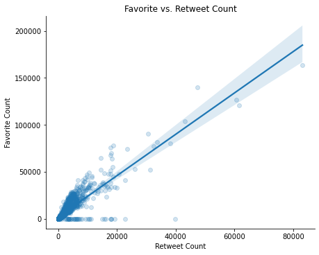

```python
#Plot scatterplot of retweet vs favorite count
sns.lmplot(x="retweet_cnt",
           y="favorite_cnt",
           data=df1,
           size = 5,
           aspect=1.3,
           scatter_kws={'alpha':1/5})
plt.title('Favorite vs. Retweet Count')
plt.xlabel('Retweet Count')
plt.ylabel('Favorite Count');
```

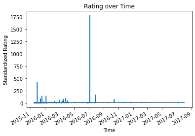

```python
# Plot standardized ratings over time
df1.groupby('timestamp')['rating_numerator'].mean().plot(kind='line')
plt.title('Rating over Time')
plt.xlabel('Time')
plt.ylabel('Standardized Rating')
plt.show;
```

- the rating in period of 2016-07 is unstandadize

There are different dog breeds in the data set we can find out the total number of breeds and the frequency or the most popular dogs

```python
# Generating a copy of the dataframe
df_breeds = df1.copy()

# Fetching the count of unique breeds
print('Unique Breeds of Dogs are : ', df_breeds['p1'].nunique())

# Calculating the frequency of various breeds
df1['p1'].value_counts()
frequency = df1['p1'].value_counts().to_dict()
f= pd.DataFrame(list(frequency.items()), columns=['breed', 'frequency'])

# Filtering the Data for frequencies > 23 only
f.drop(f[f.frequency < 23].index, inplace=True)
```

```
Unique Breeds of Dogs are :  358
```

Finding the retweets on the breeds and knowing the most popular types of breeds

```python
# Generating a new field "total_retweet"
total_retweet =[]
for i in f['breed']:
    t_r = df1[df1['p1'] == i]['retweet_cnt'].sum()
    total_retweet.append(t_r)

f['total_retweet']=total_retweet
f.head()
```

|  | breed | frequency | total_retweet |
| --- | --- | --- | --- |
| 0 | golden_retriever | 122 | 410893.0 |
| 1 | labrador_retriever | 86 | 356778.0 |
| 2 | pembroke | 77 | 228129.0 |
| 3 | chihuahua | 71 | 207081.0 |
| 4 | pug | 49 | 76780.0 |

Creating a new column for the mean of retweets

```python
# Generating a new field "retweet_mean"
f['retweet_mean']=f['total_retweet']//f['frequency']
f.head()
```

|  | breed | frequency | total_retweet | retweet_mean |
| --- | --- | --- | --- | --- |
| 0 | golden_retriever | 122 | 410893.0 | 3367.0 |
| 1 | labrador_retriever | 86 | 356778.0 | 4148.0 |
| 2 | pembroke | 77 | 228129.0 | 2962.0 |
| 3 | chihuahua | 71 | 207081.0 | 2916.0 |
| 4 | pug | 49 | 76780.0 | 1566.0 |

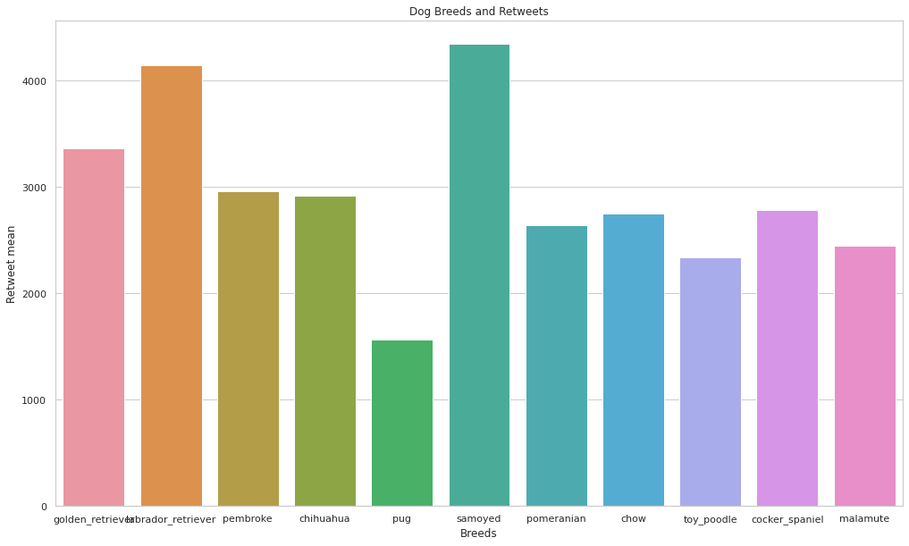

```python
# Generating a graphical plot for the data
sns.set(rc={'figure.figsize':(17,10)})

# Setting up the graph layout and design
sns.set_style("whitegrid")
g = sns.barplot(x="breed", y="retweet_mean", data=f)
g.set_ylabel('Retweet mean')

# Setting the appropriate headers
plt.title('Dog Breeds and Retweets')
plt.xlabel('Breeds')

# Exporting the figure
fig =g.get_figure()
fig.savefig('breeds_and_retweets.png')
```

The above diagram is a representation of retweets of the differrent types of breeds